# Further table-generating scenarios

Brigid Wilson

Monday, November 03, 2014

Aiming to look at further examples of data that exist as 2-by-2 (and hopefully will extend up to *j*-by-*k* tables where *j* and *k* are smallish integers indicating number of levels of qualitative variables). Starting with two that arise in work: case-control matched and pre-post assessments of a single population.

Again, want to identify the data-generating parameters, the valid tests, and the dangers of invalid tests on such data.

First: case-control matched data. Let’s assume a true conditional logistic OR of 2, not attempting to match on a confounder, merely to get a desired OR from off-diagonals.

```r
library(survival)
makeccdat <- function(n){
  x = rbinom(10*n, 1, .3)
  b = log(2)
  eta = b*x
  p = exp(eta)/(1 + exp(eta))
  y = rbinom(10*n, 1, p)
  dat0 = data.frame(x, y)
  ind.keep = c(sample(which(y == 0), n, replace = FALSE), c(sample(which(y == 1), n, replace = FALSE)))
  dat = dat0[c(ind.keep),]
  dat$id = rep(1:n, 2)
  return(dat)
}
```

Checking that, given very large sample size, this performs as expected.

```r
n = 100000
dat = makeccdat(n)
print(summary(clogit(y ~ x + strata(id), data = dat)))
```

```
## Call:
## coxph(formula = Surv(rep(1, 200000L), y) ~ x + strata(id), data = dat,
##     method = "exact")
##
##   n= 200000, number of events= 1e+05
##
##     coef exp(coef) se(coef)    z Pr(>|z|)
## x 0.6874    1.9885   0.0103 66.7   <2e-16 ***
## ---
## Signif. codes:  0 '***' 0.001 '**' 0.01 '*' 0.05 '.' 0.1 ' ' 1
##
##   exp(coef) exp(-coef) lower .95 upper .95
## x      1.99      0.503      1.95      2.03
##
## Rsquare= 0.023   (max possible= 0.5 )
## Likelihood ratio test= 4712  on 1 df,   p=0
## Wald test            = 4446  on 1 df,   p=0
## Score (logrank) test = 4624  on 1 df,   p=0
```

Have seen conditional logistic power estimations online, run a few quick checks that I’m matching their results. Match sourceforge.net, ncases = ncontrols = 217 for 90% power to detect OR = 2 when 22% of controls are exposed.

```r
pvals = rep(NA, 1000)
set.seed(1234)
for (i in 1:1000){
  tmpdat = makeccdat(217)
  pvals[i] = summary(clogit(y ~ x + strata(id), data = tmpdat))$coef[5]
}
mean(pvals < .05)
```

```
## [1] 0.891
```

Match sourceforge.net, ncases = ncontrols = 163 for 80% power.

```r
pvals = rep(NA, 1000)
set.seed(1234)
for (i in 1:1000){
  tmpdat = makeccdat(163)
  pvals[i] = summary(clogit(y ~ x + strata(id), data = tmpdat))$coef[5]
}
mean(pvals < .05)
```

```
## [1] 0.793
```

When thinking 1:1 case-control matching, typically aiming to estimate an OR; when thinking pre-post paired measurements, typically thinking more about McNemar’s. However, the two are using different parameterizations to test the equality of the off-diagonal counts (the “discordant pairs”).

Two questions: is one test more powerful than the other? And what kind of bias (or rate of false positives) is introduced by not testing without accounting for the paired/matched structure?

```r
set.seed = 2345
samp.sizes = seq(60, 300, 10)
nn = max(samp.sizes)*100
x = rbinom(nn, 1, .3)
b = log(1.5)
eta = b*x
p = exp(eta)/(1 + exp(eta))
y = rbinom(nn, 1, p)
d = data.frame(x, y)

runtests <- function(n){
  ind.keep = c(sample(which(d$y == 0), n, replace = FALSE), c(sample(which(d$y == 1), n, replace = FALSE)))
  dat = d[c(ind.keep),]
  dat$id = rep(1:n, 2)
  dat.wide = reshape(dat, timevar = "y", idvar = "id", direction = "wide")
  clmod = clogit(y ~ x + strata(id), data = dat)
  lmod = glm(y ~ x, family = "binomial", data = dat)
  mcnpval = mcnemar.test(table(dat.wide$x.0, dat.wide$x.1))$p.value
  clbeta = summary(clmod)$coef[1]
  clpval = summary(clmod)$coef[5]
  ulbeta = summary(lmod)$coef[2,1]
  ulpval = summary(lmod)$coef[2,4]
  return(c(n = n, clbeta = clbeta, clpval = clpval, ulbeta = ulbeta, ulpval = ulpval, mcnpval = mcnpval))
}

resmat = matrix(NA, nrow = length(samp.sizes)*5000, ncol = 6)

for (i in 1:length(samp.sizes)){
  for (j in 1:5000){
    resmat[5000*(i - 1) + j,] = runtests(samp.sizes[i])
  }
}
```

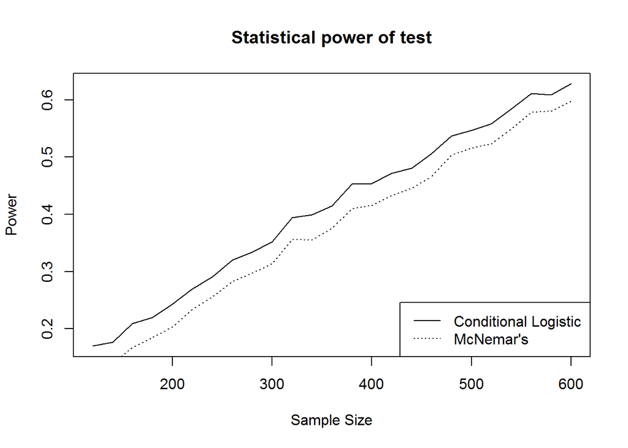

```r
pow.cl = tapply(resmat[,3], resmat[,1], function(x) mean(x < .05))
pow.ul = tapply(resmat[,5], resmat[,1], function(x) mean(x < .05))
pow.mc = tapply(resmat[,6], resmat[,1], function(x) mean(x < .05))


power = data.frame(pow.cl, pow.ul, pow.mc)
power$n = as.numeric(row.names(power))
#power2 = reshape(power, varying = c("pow.cl", "pow.ul", "pow.mc", "pow.chi"), v.names = "Power", timevar = "models", times = c("Conditional Logistic", "Logistic", "McNemar's", "Chi-Square"), direction = "long")
par(mfrow = c(1,1))
plot(x = 2*power$n, y = power$pow.cl, type = "l", lty = 1,
     main = "Statistical power of test", xlab = "Sample Size", ylab = "Power")
points(x = 2*power$n, y = power$pow.mc, type = "l", lty = 3)
legend("bottomright", c("Conditional Logistic", "McNemar's"), lty = c(1,3))
```

```r
bias.cl = tapply(resmat[,2], resmat[,1], function(x) mean(abs(x - b)))
bias.ul = tapply(resmat[,4], resmat[,1], function(x) mean(abs(x - b)))
bias = data.frame(bias.cl, bias.ul)
bias$n = as.numeric(row.names(bias))

check = makeccdat(50)
check.wide = reshape(check, timevar = "y", idvar = "id", direction = "wide")
```

Next approach: matching on an underlying confounder? Presumably ignoring this would generate biased estimates?